# constructing the components of a mixed model

## back to the general definition

$$\begin{split}
\underbrace{Y_i}_{\text{response}} & \sim
\overbrace{\text{Distr}}^{\substack{\text{conditional} \\
\text{distribution}}}(\underbrace{g^{-1}(\eta_i)}_{\substack{\text{inverse}
\\ \text{link} \\
\text{function}}},\underbrace{\phi}_{\substack{\text{scale} \\
\text{parameter}}}) \\
\underbrace{\boldsymbol \eta}_{\substack{\text{linear} \\
\text{predictor}}} &
=
\underbrace{\boldsymbol X\boldsymbol \beta}_{\substack{\text{fixed} \\
\text{effects}}} +
\underbrace{\boldsymbol Z\boldsymbol b}_{\substack{\text{random} \\
\text{effects}}}
\\
\underbrace{\boldsymbol b}_{\substack{\text{conditional} \\
\text{modes}}} &
\sim \text{MVN}(\boldsymbol 0, \underbrace{\Sigma(\boldsymbol
\theta)}_{\substack{\text{variance-} \\ \text{covariance} \\
\text{matrix}}})
\end{split}$$

## fixed-effect model matrix

- $\boldsymbol X$ ($n \times p_\textrm{fix}$)
- **terms**, **input variables**, **predictor variables**
- *Wilkinson-Rogers* notation<sup>1</sup>
- defined by `model.matrix()`, `terms()`<sup>2</sup>
- details hard to find!
- default intercept term (`1`); `-1` or `+0` to suppress
- numeric input variables → single predictor variable
- variable transformations on the fly
- *contrasts* automatically constructed for factors (unless `+0`)
- interaction `:` = pairwise products of predictor variables
- data-dependent bases: `poly()`, `splines::ns()`, etc.

## packages

```r
library(Matrix)
library(reformulas)
```

## example

```r
terms(~ mpg * disp, data = mtcars)
model.matrix(hp~ mpg * disp, data = mtcars)
```

## random-effect formulas

- formula: typically `( f | g )` (`f` = varying term, `g` = cluster/grouping variable)
- `g` can be expanded into separate terms (`(f | g1/g2)` → `(f | g1 + g1:g2)`); `*`, `+` *may* be expanded (`reformulas` package)
- `f` = any set of terms that vary *within* levels of `g`
- dialect differences
  - random component may be specified separately from fixed (e.g. `nlme::lme`, `MCMCglmm`)
  - … or as part of the same formula (e.g. `lme4`, `glmmTMB`)
  - covariance structures may be specified (`brms`, `MCMCglmm`, `glmmTMB`) as (e.g.) `cs( f | g )`
  - AS-REML-like syntax (e.g. `MCMCglmm`): e.g. `~us(f):g`
  - extensions for multi-membership models, shared variables between terms, …
- each RE term (after separation) is independent

## from RE formula to model objects: RE model matrix $\boldsymbol Z$

- details in [lmer vignette](https://cran.r-project.org/web/packages/lme4/vignettes/lmer.pdf)<sup>3</sup>
- $\boldsymbol Z$
  - *Khatri-Rao product* of $\boldsymbol J$ (indicator matrix for cluster variable `g`) with model matrix for `f`
  - e.g.:

```r
f <- factor(rep(1:3, each = 2))
Ji <- t(as(f, "sparseMatrix"))
Xi <- cbind(1, rep.int(c(-1, 1), 3L))
Zi <- t(Matrix::KhatriRao(t(Ji), t(Xi)))
```

- make $\boldsymbol J$ a **sparse** matrix, $\boldsymbol Z$ inherits structure
- concatenate $\boldsymbol Z$ from multiple terms columnwise

## from RE formula to model objects: RE covariance matrix $\Sigma$

- $\Sigma_i$ (for a single term) is block-diagonal (one block per cluster); terms are blocks too
- we may be interested in the lower-triangular *Cholesky factor* ($\Sigma = \Lambda \Lambda^\top$)
  - or the *precision matrix* (for a Gaussian model, “$x_{i}$ is conditionally independent of $x_{j}$ $\to$ $\sigma^{-1}_{ij} = 0$; enables *sparse* computations

## `lme4` example

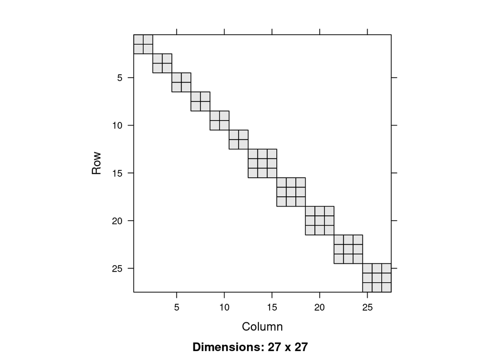

```r
dd <- expand.grid(f1 = factor(1:3), f2 = factor(1:2), g1 = factor(1:5), g2 = factor(1:6))
dd$y <- 1
form <- y ~ 1 + (f1 | g1) + (f2 | g2)
rt <- reformulas::mkReTrms(
                      bar = findbars(form),
                      fr = model.frame(subbars(form), data = dd))
Sigma <- rt$Lambdat %*% t(rt$Lambdat)
image(Sigma)
```

## references

1.

Wilkinson, G. N. & Rogers, C. E. [Symbolic description of factorial models for analysis of variance](https://doi.org/10.2307/2346786). *Applied Statistics* **22**, 392–399 (1973).

2.

Chambers, J. M. & Hastie, T. J. Statistical Models. in *Statistical Models in S* (Routledge, 1992).

3.

Bates, D., Mächler, M., Bolker, B. M. & Walker, S. C. [Fitting linear mixed-effects models using lme4](https://doi.org/10.18637/jss.v067.i01). *Journal of Statistical Software* **67**, 1–48 (2015).